# ENGR1330-Assignment2

## Assignment-2 (100 points)

**Valenzuela, Dante**

**R#12097254**

```python
# RUN this cell and do not modify it
import sys
! hostname
! whoami
print(sys.executable)
print(sys.version)
print(sys.version_info)
```

```
zsh:1: command not found: hostname
jojo
/home/jojo/anaconda3/bin/python
3.14.6 | packaged by Anaconda, Inc. | (main, Jul  9 2026, 14:37:38) [GCC 14.3.0]
sys.version_info(major=3, minor=14, micro=6, releaselevel='final', serial=0)
```

## Question 0: Data structure

#### The problem statement:

**A)Create a list of 20 arbitrary elements. The list must contain multiple integers, floats and strings. Use appropriate indexing to address a string in the list and replace thet string with its reverse.**

#### (10 points)

**B) Build a dictionary to contain the following credit score information of some individuals:**

```
Names: Sally, Dominic, Herbert, Wendy

January: 670,720,801,745

February: 689,714,799,741

March: 685,725,804,751
```

**Calculate the 3 month average credit score for each of the 4 individuals.**

#### (20 points)

```python
# A)
thisList = [1,2,3,4,5,1.0,2.0,3.0,4.0,5.0,True,False,True,False,True,"One","Two","Three","Four","Five"]
Word = thisList[19]
reversedWord = Word[::-1]

print(reversedWord)
```

```
eviF
```

```python
# B)
Sally = {
    "January":670,
    "February":689,
    "March":685,
}
Dominic = {
    "January":720,
    "February":714,
    "March":725,
}
Herbert = {
    "January":801,
    "February":799,
    "March":804,
}
Wendy = {
    "January":745,
    "February":741,
    "March":751,
}

def avg(x,y,z):
    average = (x+y+z)/3
    return average
```

```python
SallyAvg = avg(Sally["January"],Sally["February"],Sally["March"])
DominicAvg = avg(Dominic["January"],Dominic["February"],Dominic["March"])
HerbertAvg = avg(Herbert["January"],Herbert["February"],Herbert["March"])
WendyAvg = avg(Wendy["January"],Wendy["February"],Wendy["March"])

print(f"Sally: {SallyAvg:.2f}, Dominic: {DominicAvg:.2f}, Herbert: {HerbertAvg:.2f}, Wendy: {WendyAvg:.2f}")
```

```
Sally: 681.33, Dominic: 719.67, Herbert: 801.33, Wendy: 745.67
```

## Question 1: Algorithm

#### The problem statement:

**Calculate the average of any three numbers and report whether it is a whole number or not.**

**Consider your solution, write your algorithm in a markdown cell and design your flowchart. Draw your flowchart (either on paper or using software e.g. PowerPoint) and attach a screenshot.**

(If you are unable to insert the image, then separately upload it on blackboard)

#### (10 points)

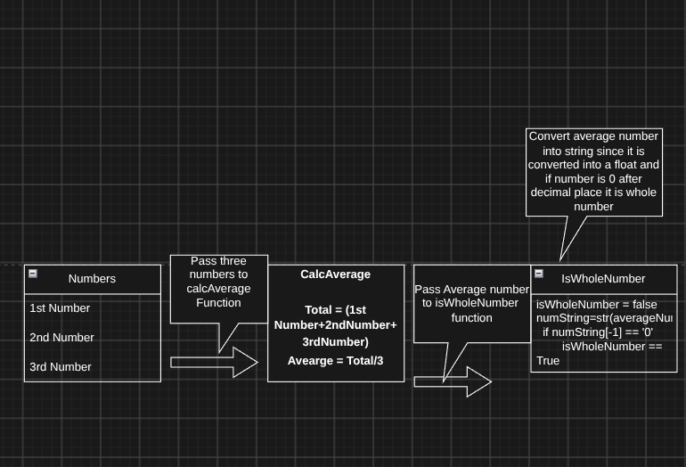

## Question 2: Conditionals

**Write a code based on the description below:**

**Ask the user to enter an ineteger number between 1 and 111.**

**Use try-except block to replace the entered value by 0 if the entered number is not an integer.**

**Use another try-except block to replace the entered number by 1, if the entered number is greater than 111. (Clue: come up with a code that will generate error if the number is greater then 111. Hint: python gives error if division by zero is attempted ;) )**

**Once done, perform the following tasks (out of try-except blocks)**

> **Check whether the number is a prime number (i.e. indivisible by 2,3,5 and 7, all of them). If found so, then print: "You entered ... and its a prime number!!" (use string formatting to display the number)**  
> **If not, then check if the number is divisible by 3, 5 and 7 (all 3 of them), if found so, then print a message "You must have entered 105!".**  
> **If not, then check if its divisible by either 3 or 5 or 7, then print "OH STOP NOW"**  
> **Otherwise, just print: "Oh I see, your number must be a multiple of 4, if not a 0!!"**

```
a. 113
b. 36.2
c. 41
d. 105
e. 25
f. 88
```

#### (60 points)

```python
num = input('Enter a number between 1 and 111')
try:
   num = int(num)
except:
    num = 0

try:
    if num > 111:
        1/0
except:
    num = 1

if num % 2 != 0 and num % 3 != 0 and num % 5 != 0 and num % 7 != 0:
    print(f'You entered {num} and its a prime number!!')
elif num != 0 and num % 3 == 0 and num % 5 == 0 and num % 7 == 0:
    print('You must have entered 105')
elif num != 0 and (num % 3 == 0 or num % 5 == 0 or num % 7 == 0):
    print('OH STOP NOW')
else:
    print('Oh i see, Your number must be a multiple of 4, if not a 0')

print(num)
```

```
Oh i see, Your number must be a multiple of 4, if not a 0
88
```

```python
# a.
```

[output not shown]

```python
# b.
```

[output not shown]

```python
# c.
```

[output not shown]

```python
# d.
```

[output not shown]

```python
# e.
```

[output not shown]

```python
# f.
```

[output not shown]